# Sparkify Data Workspace

For reasons of clarity the Sparkify project has been split into two notebooks, this is part 1.  
Data exploration and development of features will take place in this notebook, while modeling to predict customer churn is part 2, in the Sparkify_Modeling.ipynb notebook. For that reason the features engineered in this notebook are written to a Parquet file mini_sparkify_feature_data.parquet at the end of the notebook for easier data handling and further use in part 2.

The data used for this project is the mini_sparkify_event_data.json dataset provided by Udacity, containing 128MB of the full dataset available (12GB). Usage of a bigger dataset is not advised within the Udacity workspace for computation time reasons.

### Content:

- Imports and setup
- Load and Clean Dataset
- Exploratory Data Analysis
- Feature Engineering
- Next Steps

#### Import libraries

```python
import pandas as pd
import numpy as np
import matplotlib.pyplot as plt
%matplotlib inline
import datetime
import re
import seaborn as sns

from pyspark import SparkConf, SparkContext
from pyspark.sql import SparkSession, Window
import pyspark.sql.functions as F
from pyspark.sql.functions import udf, desc, asc, sum as Fsum, isnan, when, count, col
from pyspark.sql.types import StringType, IntegerType, ArrayType

from IPython.display import display as d
```

#### Create a Spark session

```python
# create the Spark session
spark = SparkSession \
            .builder \
            .appName("sparkify") \
            .getOrCreate()

# show Spark config details
d(spark)
d(spark.sparkContext.getConf().getAll())
```

**SparkSession - in-memory**

**SparkContext**

[Spark UI](http://6760b8203f04:4040)

**Version**

`v2.4.3`

**Master**

`local[*]`

**AppName**

`sparkify`

```
[('spark.app.id', 'local-1625390193920'),
 ('spark.driver.port', '34731'),
 ('spark.app.name', 'sparkify'),
 ('spark.rdd.compress', 'True'),
 ('spark.driver.host', '6760b8203f04'),
 ('spark.serializer.objectStreamReset', '100'),
 ('spark.master', 'local[*]'),
 ('spark.executor.id', 'driver'),
 ('spark.submit.deployMode', 'client'),
 ('spark.ui.showConsoleProgress', 'true')]
```

# Load and Clean Dataset

The dataset `mini_sparkify_event_data.json` is loaded into a Spark DataFrame and checked for invalid or missing data, a common issue of big datasets. User log records, that are of no use for data exploration or feature engineering are dropped from the dataset.

```python
file_location = "mini_sparkify_event_data.json"
sdf = spark.read.json(file_location)
sdf.persist()
sdf.printSchema()
```

```
root
 |-- artist: string (nullable = true)
 |-- auth: string (nullable = true)
 |-- firstName: string (nullable = true)
 |-- gender: string (nullable = true)
 |-- itemInSession: long (nullable = true)
 |-- lastName: string (nullable = true)
 |-- length: double (nullable = true)
 |-- level: string (nullable = true)
 |-- location: string (nullable = true)
 |-- method: string (nullable = true)
 |-- page: string (nullable = true)
 |-- registration: long (nullable = true)
 |-- sessionId: long (nullable = true)
 |-- song: string (nullable = true)
 |-- status: long (nullable = true)
 |-- ts: long (nullable = true)
 |-- userAgent: string (nullable = true)
 |-- userId: string (nullable = true)
```

```python
# show top user IDs
print("User IDs:")
sdf.select("userId").distinct().sort("userId").show(3)

# show pages visited by user without ID
print("Pages visited by visitors:")
sdf.filter("userId == ''").select("page").distinct().sort("page").show()
```

```
User IDs:
+------+
|userId|
+------+
|      |
|    10|
|   100|
+------+
only showing top 3 rows

Pages visited by visitors:
+-------------------+
|               page|
+-------------------+
|              About|
|              Error|
|               Help|
|               Home|
|              Login|
|           Register|
|Submit Registration|
+-------------------+
```

> User(s) without user ID are probably visitors, since they only visit public pages (i.e. accessible without subscription).  
> Those users are not interesting for churn evaluation and are therefore exluded.

```python
# exclude visitors
sdf = sdf.filter("userId != ''")
```

```python
# drop rows with null values?
print("Number of null values: %s\n" % (sdf.count() - sdf.dropna(how="any").count()))
sdf.filter("page != 'NextSong'").show(3)
```

```
Number of null values: 50046

+------+---------+---------+------+-------------+--------+------+-----+--------------------+------+---------------+-------------+---------+----+------+-------------+--------------------+------+
|artist|     auth|firstName|gender|itemInSession|lastName|length|level|            location|method|           page| registration|sessionId|song|status|           ts|           userAgent|userId|
+------+---------+---------+------+-------------+--------+------+-----+--------------------+------+---------------+-------------+---------+----+------+-------------+--------------------+------+
|  null|Logged In|    Colin|     M|           54| Freeman|  null| paid|     Bakersfield, CA|   PUT|Add to Playlist|1538173362000|       29|null|   200|1538352905000|Mozilla/5.0 (Wind...|    30|
|  null|Logged In|    Micah|     M|           84|    Long|  null| free|Boston-Cambridge-...|   GET|    Roll Advert|1538331630000|        8|null|   200|1538353150000|"Mozilla/5.0 (Win...|     9|
|  null|Logged In|    Micah|     M|           86|    Long|  null| free|Boston-Cambridge-...|   PUT|      Thumbs Up|1538331630000|        8|null|   307|1538353376000|"Mozilla/5.0 (Win...|     9|
+------+---------+---------+------+-------------+--------+------+-----+--------------------+------+---------------+-------------+---------+----+------+-------------+--------------------+------+
only showing top 3 rows
```

> Looking at the null values, those are all from non-listening interactions. Since they contain information on advertisements, downgrades etc. those rows cannot be dropped.

# Exploratory Data Analysis

- Performing EDA to get an understanding of the data
- Do some preselection of features
- Compare data from users who stayed vs. users who churned

### Transform features, define *churn* and select important features for exploration

These transformations and feature creation steps have been developed step by step and finally put into one function to apply to the dataset.

```python
def transform_data(dataframe):
    """
    Transform, create and drop features from dataframe
    INPUTS:
    dataframe: Spark dataframe to transform
    """

    dataframe = dataframe.filter("userId != ''")

    # transform device information
    device_udf = udf(lambda x: "iPhone" if "iPhone" in x else
                     ("Mac OS" if "Mac OS" in x else
                      ("iPad" if "iPad" in x else
                       ("Ubuntu" if "Ubuntu" in x else
                        ("Windows" if "Windows" in x else "unknown")))))
    dataframe = dataframe.withColumn("device", device_udf(dataframe.userAgent))

    # transform gender information
    gender_udf = udf(lambda x: 1 if x == "F" else 0)
    dataframe = dataframe.withColumn("gender", gender_udf(dataframe.gender))

    # transform level information
    level_udf = udf(lambda x: 1 if x == "paid" else 0)
    dataframe = dataframe.withColumn("level", level_udf(dataframe.level))

    # transform states
    state_udf = udf(lambda x: re.findall(re.compile(r",\s(.+)"), x)[0])
    dataframe = dataframe.withColumn("location", state_udf(dataframe.location))

    # reduce dataframe to important features
    dataframe = dataframe.select('gender', 'length', 'level', "location", 'page',
                                 'sessionId', "device", 'ts', 'userId', "registration")

    # udfs for timestamp transformation
    get_timestamp = udf(lambda x: datetime.datetime.fromtimestamp(x / 1000.0).strftime("%Y-%m-%d %H:%M:%S"))
    get_timestamp_short = udf(lambda x: datetime.datetime.fromtimestamp(x / 1000.0).strftime("%Y-%m-%d"))
    get_hour_udf = udf(lambda x: int(datetime.datetime.fromtimestamp(x / 1000.0).hour))
    get_wday_udf = udf(lambda x: int(datetime.datetime.fromtimestamp(x / 1000.0).weekday()))
    get_day_udf = udf(lambda x: int(datetime.datetime.fromtimestamp(x / 1000.0).day))
    get_month_udf = udf(lambda x: int(datetime.datetime.fromtimestamp(x / 1000.0).month))
    get_year_udf = udf(lambda x: int(datetime.datetime.fromtimestamp(x / 1000.0).year))
    get_month_year_udf = udf(lambda x: str(datetime.datetime.fromtimestamp(x / 1000.0).year)
                             + "/" + str(datetime.datetime.fromtimestamp(x / 1000.0).month))
    get_week_udf = udf(lambda x: str(datetime.date.isocalendar(datetime.datetime.fromtimestamp(x / 1000.0))[1]))
    get_week_year_udf = udf(lambda x: str(datetime.datetime.fromtimestamp(x / 1000.0).year)
                            + "/" + str(datetime.date.isocalendar(datetime.datetime.fromtimestamp(x / 1000.0))[1]))
    get_timedelta_udf = udf(lambda x, y: (datetime.datetime.fromtimestamp(y / 1000.0)
                                          - datetime.datetime.fromtimestamp(x / 1000.0)).total_seconds()
                                          / 60 / 60 / 24 if x != 0 else 0)
    # get month/year of registration
    dataframe = dataframe.withColumn("reg_month_year", get_month_year_udf(dataframe.registration))
    dataframe = dataframe.withColumn("reg_week_year", get_week_year_udf(dataframe.registration))#.drop("registration")
    # get time features for timestamp
    dataframe = dataframe.withColumn("ts_hour", get_hour_udf(dataframe.ts).cast("int"))
    dataframe = dataframe.withColumn("ts_day", get_day_udf(dataframe.ts).cast("int"))
    dataframe = dataframe.withColumn("ts_week", get_week_udf(dataframe.ts).cast("int"))
    dataframe = dataframe.withColumn("ts_month", get_month_udf(dataframe.ts).cast("int"))
    dataframe = dataframe.withColumn("ts_year", get_year_udf(dataframe.ts).cast("int"))
    dataframe = dataframe.withColumn("ts_wday", get_wday_udf(dataframe.ts).cast("int"))
    dataframe = dataframe.withColumn("ts_week_year", get_week_year_udf(dataframe.ts))#.drop("ts")
    dataframe = dataframe.withColumn("membership_days", get_timedelta_udf(dataframe.registration, dataframe.ts).cast("int"))
    # previous timestamps
    dataframe = dataframe.withColumn("ts_prev", F.lag(dataframe.ts, default=0)
                                     .over(Window.partitionBy("userId").orderBy("ts")).cast("long"))
    # timedelta to previous interaction
    dataframe = dataframe.withColumn("ts_delta_minutes", F.round((get_timedelta_udf(dataframe.ts_prev, dataframe.ts)
                                                                  * 24 * 60).cast("float"), 2))
    dataframe = dataframe.withColumn("ts_short", (get_timestamp_short(dataframe.ts)).cast("string"))
    dataframe = dataframe.withColumn("ts", (get_timestamp(dataframe.ts)).cast("string"))
    dataframe = dataframe.drop("ts_prev", "registration")

    # define churn based on cancellation confirmation event
    churn_udf = udf(lambda x: 1 if x == "Cancellation Confirmation" else 0)
    upgrade_udf = udf(lambda x: 1 if x == "Submit Upgrade" else 0)
    downgrade_udf = udf(lambda x: 1 if x == "Submit Downgrade" else 0)
    dataframe = dataframe.withColumn("downgrade", downgrade_udf("page").cast("int")) \
                         .withColumn("usr_down", F.sum("downgrade").over(Window.partitionBy("userId")).cast("int")) \
                         .withColumn("churn", churn_udf("page").cast("int")) \
                         .withColumn("usr_churn", F.sum("churn").over(Window.partitionBy("userId")).cast("int")) \
                         .withColumn("upgrade", upgrade_udf("page").cast("int")) \
                         .withColumn("usr_up", F.sum("upgrade").over(Window.partitionBy("userId")).cast("int"))
    return dataframe
```

```python
sdf = transform_data(sdf).persist()
sdf.show(5)
```

```
+------+---------+-----+--------+---------+---------+------+-------------------+------+--------------+-------------+-------+------+-------+--------+-------+-------+------------+---------------+----------------+----------+---------+--------+-----+---------+-------+------+
|gender|   length|level|location|     page|sessionId|device|                 ts|userId|reg_month_year|reg_week_year|ts_hour|ts_day|ts_week|ts_month|ts_year|ts_wday|ts_week_year|membership_days|ts_delta_minutes|  ts_short|downgrade|usr_down|churn|usr_churn|upgrade|usr_up|
+------+---------+-----+--------+---------+---------+------+-------------------+------+--------------+-------------+-------+------+-------+--------+-------+-------+------------+---------------+----------------+----------+---------+--------+-----+---------+-------+------+
|     1|202.97098|    0|      CT| NextSong|       31|iPhone|2018-10-08 12:58:54|100010|        2018/9|      2018/39|     12|     8|     41|      10|   2018|      0|     2018/41|             11|             0.0|2018-10-08|        0|       0|    0|        0|      0|     0|
|     1|196.54485|    0|      CT| NextSong|       31|iPhone|2018-10-08 13:02:16|100010|        2018/9|      2018/39|     13|     8|     41|      10|   2018|      0|     2018/41|             11|            3.37|2018-10-08|        0|       0|    0|        0|      0|     0|
|     1|263.13098|    0|      CT| NextSong|       31|iPhone|2018-10-08 13:05:32|100010|        2018/9|      2018/39|     13|     8|     41|      10|   2018|      0|     2018/41|             11|            3.27|2018-10-08|        0|       0|    0|        0|      0|     0|
|     1|     null|    0|      CT|Thumbs Up|       31|iPhone|2018-10-08 13:05:33|100010|        2018/9|      2018/39|     13|     8|     41|      10|   2018|      0|     2018/41|             11|            0.02|2018-10-08|        0|       0|    0|        0|      0|     0|
|     1|316.23791|    0|      CT| NextSong|       31|iPhone|2018-10-08 13:09:55|100010|        2018/9|      2018/39|     13|     8|     41|      10|   2018|      0|     2018/41|             11|            4.37|2018-10-08|        0|       0|    0|        0|      0|     0|
+------+---------+-----+--------+---------+---------+------+-------------------+------+--------------+-------------+-------+------+-------+--------+-------+-------+------------+---------------+----------------+----------+---------+--------+-----+---------+-------+------+
only showing top 5 rows
```

### Data exploration, Part 1 - some general EDA to get an understanding of the data

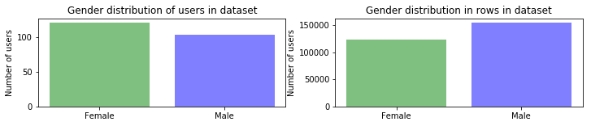

```python
# information on gender of users in the dataset
plt.figure(figsize=(12, 2));

user_gender = sdf.select("userId", "gender").distinct().groupby("gender").count().toPandas()
plt.subplot(1, 2, 1);
plt.bar(data=user_gender, x="gender", height="count", tick_label=["Female", "Male"], color=["g", "b"], alpha=0.5);
plt.title("Gender distribution of users in dataset");
plt.ylabel("Number of users");

data_gender = sdf.select("userId", "gender").filter("userId != ''").dropna(how="any").groupby("gender").count().toPandas()
plt.subplot(1, 2, 2);
plt.bar(data=data_gender, x="gender", height="count", tick_label=["Female", "Male"], color=["g", "b"], alpha=0.5);
plt.title("Gender distribution in rows in dataset");
plt.ylabel("Number of users");
```

> While more female users appear in the given dataset, the male users show more interactions than female users.

```python
# get some information on advertisements shown to users
print("Total number of advertisements:", sdf.select("page").filter("page == 'Roll Advert'").count())
print("Number of advertisements for free users:",
      sdf.select("page", "level").filter("page == 'Roll Advert'").filter("level == 0").count())
print("Number of advertisements for paid users:",
      sdf.select("page", "level").filter("page == 'Roll Advert'").filter("level == 1").count())
```

```
Total number of advertisements: 3933
Number of advertisements for free users: 3687
Number of advertisements for paid users: 246
```

> Users on paid subscription also get advertisements, although much less than free users

```python
# stats on downgrade and cancellation events
users_downgrade = sdf.filter("page == 'Downgrade'").select("userId").distinct()
users_submit_downgrade = sdf.filter("page == 'Submit Downgrade'").select("userId").distinct()
users_cancelled = sdf.filter("page == 'Cancellation Confirmation'").select("userId").distinct()

print("Number of 'Downgrade' events:", sdf.filter("page == 'Downgrade'").count())
print("Number of users who visited 'Downgrade':", users_downgrade.count())
print("\nNumber of 'Submit Downgrade' events:", sdf.filter("page == 'Submit Downgrade'").count())
print("Number of users who submitted a downgrade:", users_submit_downgrade.count())
print("\nNumber of 'Cancellation Confirmation' events:", sdf.filter("page == 'Cancellation Confirmation'").count())
print("Number of users who cancelled their subscription:", users_cancelled.count())
```

```
Number of 'Downgrade' events: 2055
Number of users who visited 'Downgrade': 154

Number of 'Submit Downgrade' events: 63
Number of users who submitted a downgrade: 49

Number of 'Cancellation Confirmation' events: 52
Number of users who cancelled their subscription: 52
```

> Many users visited the 'Downgrade' page, most of them apparently multiple times.  
> But only 63 downgrades were actually submitted by 49 users, so some users must have upgraded/downgraded several times.  
> 52 users cancelled their subscription.

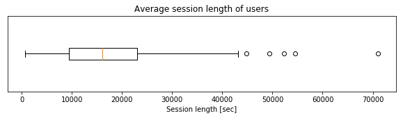

```python
# average length of a streaming session
session_length_avg = sdf.select("userId", "sessionId", "length").groupby("userId", "sessionId") \
                        .agg(F.sum("length")).sort("userId").groupby("userId") \
                        .agg(F.avg("sum(length)").alias("avg_session_length")).toPandas()

plt.figure(figsize=(10,2))
plt.boxplot(session_length_avg.avg_session_length, vert=False);
plt.title("Average session length of users");
plt.xlabel("Session length [sec]");
plt.tick_params(labelleft=False, left=False)
```

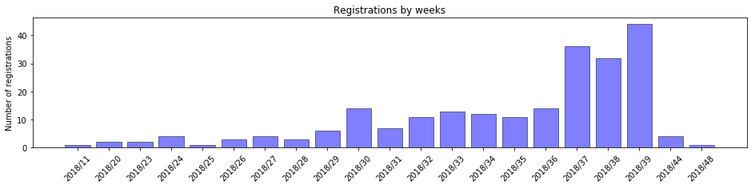

```python
# week of registration
reg_by_week = sdf.select("reg_week_year", "userId") \
                 .distinct().groupby("reg_week_year").count() \
                 .sort("reg_week_year", ascending=False).toPandas()
plt.figure(figsize=(16, 3))
plt.bar(data=reg_by_week, x="reg_week_year", height="count", alpha=0.5, color=[0, 0, 1], edgecolor="b");
plt.title("Registrations by weeks");
plt.ylabel("Number of registrations");
plt.xticks(rotation=45);
```

> In this small dataset most users signed up in September 2018. More precisely, most users registered on week 37 to 39, with a significant drop after week 39.

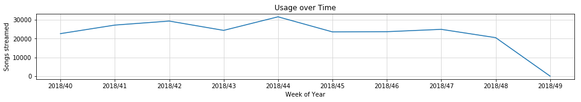

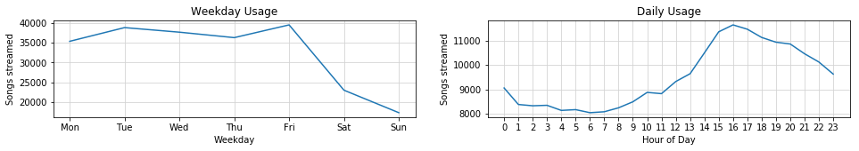

```python
# some statistics on usage over time
pd_usage_weekday = sdf.filter("page == 'NextSong'").groupby("ts_wday").count().sort(sdf.ts_wday.cast("int")).toPandas()
pd_usage_hour = sdf.filter("page == 'NextSong'").groupby("ts_hour").count().sort(sdf.ts_hour.cast("int")).toPandas()
pd_usage_week_year = sdf.filter("page == 'NextSong'").groupby("ts_week_year").count().sort(sdf.ts_week_year).toPandas()

plt.figure(figsize=(16, 2))
plt.plot(pd_usage_week_year.index, pd_usage_week_year["count"]);
plt.title("Usage over Time");
plt.xlabel("Week of Year");
plt.ylabel("Songs streamed");
plt.grid(color="LightGrey");
index = range(len(pd_usage_week_year["ts_week_year"]));
plt.xticks(index, pd_usage_week_year["ts_week_year"]);

plt.figure(figsize=(16, 2))

plt.subplot(1, 2, 1)
plt.plot(pd_usage_weekday["ts_wday"], pd_usage_weekday["count"]);
plt.title("Weekday Usage");
plt.xlabel("Weekday");
plt.ylabel("Songs streamed");
plt.grid(color="LightGrey")
index = range(len(pd_usage_weekday["ts_wday"]))
plt.xticks(index, ["Mon", "Tue", "Wed", "Thu", "Fri", "Sat", "Sun"])

plt.subplot(1, 2, 2)
pd_usage_hour.ts_hour = pd.to_numeric(pd_usage_hour.ts_hour)
plt.plot(pd_usage_hour["ts_hour"], pd_usage_hour["count"]);
plt.title("Daily Usage");
plt.xlabel("Hour of Day");
plt.ylabel("Songs streamed");
plt.grid(color="LightGrey")
plt.xticks(range(24));
```

```python
def plot_page_time(subpage):
    """
    Plot histogram of page timestamps for given subpage
    INPUTS:
    subpage: page to build histogram on
    """

    data = sdf.filter("page == '" + subpage + "'").toPandas()

    plt.figure(figsize=(16, 2))
    plt.subplot(1, 2, 1)
    plt.hist(data.ts_wday, bins=np.arange(0, 8)-0.5, color=[0, 0, 1], alpha=0.5, edgecolor="b");
    plt.xlabel("Day of Week");
    plt.ylabel(subpage);
    plt.xticks(range(7), ["Mon", "Tue", "Wed", "Thu", "Fri", "Sat", "Sun"]);

    plt.subplot(1, 2, 2)
    plt.hist(data.ts_hour, bins=np.arange(0, 24)-0.5, color=[0, 0, 1], alpha=0.5, edgecolor="b");
    plt.xlabel("Hour of Day");
    plt.ylabel(subpage);
    plt.xticks([i for i in range(0, 23)]);
```

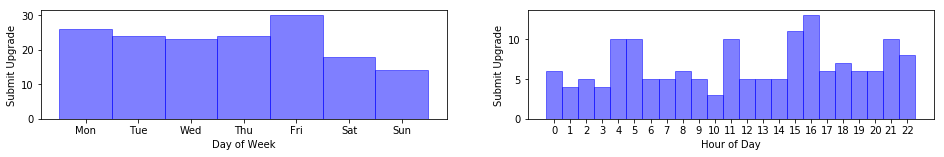

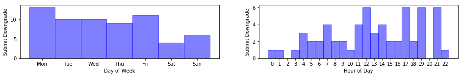

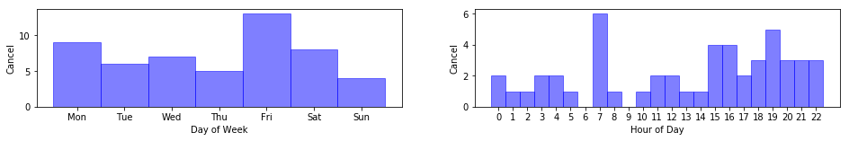

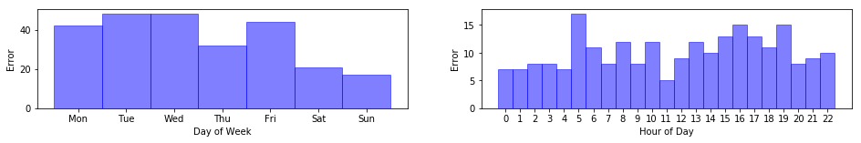

```python
# is there a time pattern for upgrading/downgrading/cancelling interactions with the streaming service?
plot_page_time("Submit Upgrade")
plot_page_time("Submit Downgrade")
plot_page_time("Cancel")
plot_page_time("Error")
```

> Changing the level of subscription mostly follows the general usage time pattern, as shown in the plots above.  
> Cancellations look basically similar, but have a more pronounced peak on fridays and saturdays and at 7am.

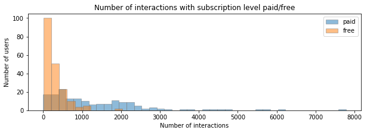

```python
# distribution of interactions on paid/free subscription
feat_paid_interaction_cnt = sdf.filter("level == 1").select("userId") \
                               .groupby("userId").count().withColumnRenamed("count", "paid_interaction_cnt")
feat_free_interaction_cnt = sdf.filter("level == 0").select("userId") \
                               .groupby("userId").count().withColumnRenamed("count", "free_interaction_cnt")

pd_feat_paid_interaction_cnt = feat_paid_interaction_cnt.toPandas()
pd_feat_free_interaction_cnt = feat_free_interaction_cnt.toPandas()
plt.figure(figsize=(10, 3))
plt.hist(pd_feat_paid_interaction_cnt.paid_interaction_cnt, alpha=0.5, bins=40, edgecolor="grey");
plt.hist(pd_feat_free_interaction_cnt.free_interaction_cnt, alpha=0.5, bins=10, edgecolor="grey");
plt.legend(["paid", "free"]);
plt.title("Number of interactions with subscription level paid/free");
plt.xlabel("Number of interactions");
plt.ylabel("Number of users");
```

> Users with paid subscriptions use the service more often or more longterm resulting in more interactions on paid subscriptions.

### Data exploration, Part 2 - comparing churning vs. staying users & feature creation

```python
# some stats on users
unique_users = sdf.select("userId").distinct()
cancellations = sdf.filter(sdf.page == "Cancellation Confirmation").select("userId").distinct().count()
print("Number of users:", unique_users.count())
print("Number of users, who cancelled their subscription:", cancellations)
print(f"Churn rate (based on small dataset): {round(cancellations / unique_users.count() * 100, 1)}%")
```

```
Number of users: 225
Number of users, who cancelled their subscription: 52
Churn rate (based on small dataset): 23.1%
```

```python
# base Spark dataframe to which relevant features are added
features = sdf.select("userId", "usr_churn", "gender").groupby("userId") \
              .agg({"usr_churn":"max"}).withColumnRenamed("max(usr_churn)", "churn_flag")
features.show(3)
```

```
+------+----------+
|userId|churn_flag|
+------+----------+
|100010|         0|
|200002|         0|
|   125|         1|
+------+----------+
only showing top 3 rows
```

```python
# average usage during membership
feat_membership = sdf.select("membership_days", "userId").groupby("userId") \
                        .agg(F.max("membership_days").alias("membership_duration"),
                             F.countDistinct("membership_days").alias("days_active")) \
                        .withColumn("active_rate", F.round(col("days_active") / col("membership_duration"), 2)).fillna(0)
feat_membership.show(3)
```

```
+------+-------------------+-----------+-----------+
|userId|membership_duration|days_active|active_rate|
+------+-------------------+-----------+-----------+
|100010|                 55|          7|       0.13|
|200002|                 70|          8|       0.11|
|   125|                 71|          1|       0.01|
+------+-------------------+-----------+-----------+
only showing top 3 rows
```

```python
# percentage of interactions while on paid subscription
feat_level_interactions = sdf.select("userId", "level").groupBy("userId") \
                                .agg(F.avg("level").alias("paid_use_share")) \
                                .withColumn("paid_use_share", F.round(col("paid_use_share"), 2)).fillna(0)
feat_level_interactions.show(3)
```

```
+------+--------------+
|userId|paid_use_share|
+------+--------------+
|100010|           0.0|
|200002|          0.75|
|   125|           0.0|
+------+--------------+
only showing top 3 rows
```

```python
# percentage of membership time on paid/free subscription for each user
feat_level_subscription = sdf.select("level", "userId", "ts_week_year").groupby("userId", "ts_week_year") \
                                .agg(F.avg("level").alias("weekly_avg")).groupby("userId") \
                                .agg(F.avg("weekly_avg").alias("paid_sub_share")) \
                                .withColumn("paid_sub_share", F.round(col("paid_sub_share"), 2))
feat_level_subscription.show(3)
```

```
+------+--------------+
|userId|paid_sub_share|
+------+--------------+
|100010|           0.0|
|200002|          0.64|
|   125|           0.0|
+------+--------------+
only showing top 3 rows
```

```python
# number of interactions for each page
feat_page = sdf.select("userId", "page").groupBy("userId").pivot("page").agg(F.count("page")) \
                .drop("Cancel", "Cancellation Confirmation", "Save Settings", "Settings", "Logout").fillna(0)
feat_page = feat_page.select([col(c).alias("page_" + c.replace(" ", "")) if c != "userId" else c for c in feat_page.columns])
feat_page.show(3)
```

```
+------+----------+--------------+------------------+--------------+----------+---------+---------+-------------+---------------+--------------------+------------------+---------------+-------------+------------+
|userId|page_About|page_AddFriend|page_AddtoPlaylist|page_Downgrade|page_Error|page_Help|page_Home|page_NextSong|page_RollAdvert|page_SubmitDowngrade|page_SubmitUpgrade|page_ThumbsDown|page_ThumbsUp|page_Upgrade|
+------+----------+--------------+------------------+--------------+----------+---------+---------+-------------+---------------+--------------------+------------------+---------------+-------------+------------+
|100010|         1|             4|                 7|             0|         0|        2|       11|          275|             52|                   0|                 0|              5|           17|           2|
|200002|         3|             4|                 8|             5|         0|        2|       20|          387|              7|                   0|                 1|              6|           21|           2|
|   125|         0|             0|                 0|             0|         0|        0|        0|            8|              1|                   0|                 0|              0|            0|           0|
+------+----------+--------------+------------------+--------------+----------+---------+---------+-------------+---------------+--------------------+------------------+---------------+-------------+------------+
only showing top 3 rows
```

```python
# device used
feat_device = sdf.select("userId", "device").groupBy("userId").pivot("device").agg(F.countDistinct("device")).fillna(0)
feat_device = feat_device.select([col(c).alias("device_" + c.replace(" ", ""))
                                  if c != "userId" else c for c in feat_device.columns])
feat_device.show(3)
```

```
+------+------------+-------------+--------------+-------------+--------------+
|userId|device_MacOS|device_Ubuntu|device_Windows|device_iPhone|device_unknown|
+------+------------+-------------+--------------+-------------+--------------+
|100010|           0|            0|             0|            1|             0|
|200002|           0|            0|             0|            1|             0|
|   125|           1|            0|             0|            0|             0|
+------+------------+-------------+--------------+-------------+--------------+
only showing top 3 rows
```

```python
# average session length for each user
feat_session_length = sdf.select("userId", "sessionId", "page").groupby("userId", "sessionId") \
                            .agg(F.count("page").alias("avg_session")).groupby("userId") \
                            .agg(F.avg("avg_session").alias("avg_session_len")) \
                            .withColumn("avg_session_len", F.round(col("avg_session_len"), 2))
feat_session_length.show(3)
```

```
+------+---------------+
|userId|avg_session_len|
+------+---------------+
|100010|          54.43|
|200002|           79.0|
|   125|           11.0|
+------+---------------+
only showing top 3 rows
```

```python
# average daily listening time
feat_daily_time = sdf.select("userId", "ts_short", "length").groupby("userId", "ts_short") \
                        .agg(F.sum("length").alias("day_len")).groupby("userId") \
                        .agg(F.avg("day_len").cast("int").alias("avg_day_len"))
feat_daily_time.show(3)
```

```
+------+-----------+
|userId|avg_day_len|
+------+-----------+
|100010|       9562|
|200002|      13429|
|   125|       2089|
+------+-----------+
only showing top 3 rows
```

```python
# feature to differentiate gender
feat_gender = sdf.select("userId", "gender").groupby("userId").agg(F.avg("gender").cast("int").alias("gender"))
feat_gender.show(3)
```

```
+------+------+
|userId|gender|
+------+------+
|100010|     1|
|200002|     0|
|   125|     0|
+------+------+
only showing top 3 rows
```

```python
# feature to differentiate user location
feat_location = sdf.select("userId", "location").groupby("userId") \
                   .agg(F.max("location").alias("location")).fillna("unknown")
feat_location.show(3)
```

```
+------+--------+
|userId|location|
+------+--------+
|100010|      CT|
|200002|IL-IN-WI|
|   125|      TX|
+------+--------+
only showing top 3 rows
```

```python
def plot_hist_agg_compare(pd_df, column, bins):
    """
    Plot histogram from pandas dataframe, comparing churned/stayed users by churn_flag
    INPUTS:
    pd_df: pandas dataframe containing the relevant feature
    column: feature to plot in histogram
    bins: number if bins for histogram
    """

    plt.figure(figsize=(12, 2.5));
    plt.hist(pd_df[pd_df.churn_flag == 1][column], alpha=0.5, bins=bins, normed=True, color=[1, 0, 0]);
    plt.hist(pd_df[pd_df.churn_flag == 0][column], alpha=0.5, bins=bins, normed=True, color=[0, 0, 1]);
    plt.legend(["churn", "stay"]);
    plt.title(column + " for users who churned/stayed");
    plt.xlabel(column);
    plt.ylabel("Density");
```

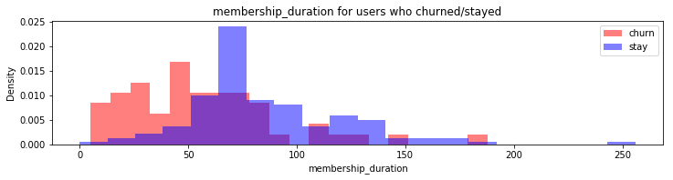

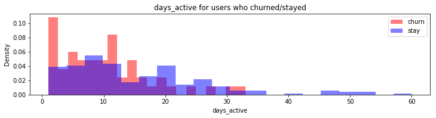

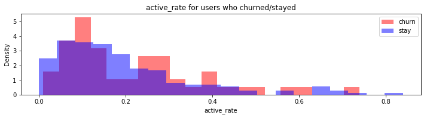

```python
plot_hist_agg_compare(features.join(feat_membership,on=['userId'], how='left').toPandas(), "membership_duration", 20)
plot_hist_agg_compare(features.join(feat_membership,on=['userId'], how='left').toPandas(), "days_active", 20)
plot_hist_agg_compare(features.join(feat_membership,on=['userId'], how='left').toPandas(), "active_rate", 20)
```

> Users who stay with the service have a more long term membership than users who churn.  
> But users who churn don't show a significantly lower activity during their membership.

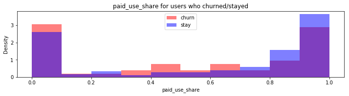

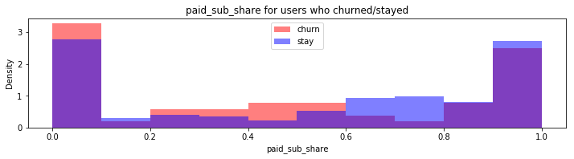

```python
plot_hist_agg_compare(features.join(feat_level_interactions,on=['userId'], how='left').toPandas(), "paid_use_share", 10)
plot_hist_agg_compare(features.join(feat_level_subscription,on=['userId'], how='left').toPandas(), "paid_sub_share", 10)
```

> The distribution of users with a high share of paid usage shows a tendency for churning users being the ones with less interactions during paid subscription.  
> This is emphasized by looking at the paid share of the membership time for the users, showing slighlty less time on paid subscription for churning users.

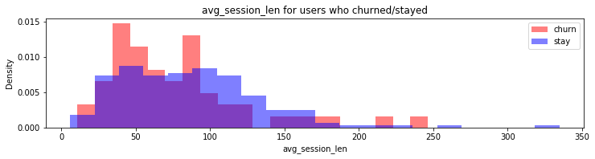

```python
plot_hist_agg_compare(features.join(feat_session_length,on=['userId'], how='left').toPandas(), "avg_session_len", 20)
```

> The average session length seems to be slightly shorter for users who churned vs. users who stayed.

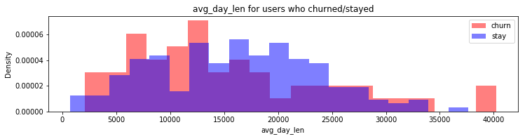

```python
plot_hist_agg_compare(features.join(feat_daily_time,on=['userId'], how='left').toPandas(), "avg_day_len", 20)
```

> The daily listening time is slightly shorter for users who churn.

```python
def plot_page_churn(columns):
    """
    Plot a barplot for each of the given categories of the page feature
    INPUTS:
    columns: columns to plot
    """
    num = np.ceil(len(columns) / 3)
    plt.figure(figsize=(16, 12));
    for i, column in enumerate(columns):
        friends_churn = sdf.filter(col("page") == column).filter(sdf.usr_churn > 0) \
                           .select("page", "userId").groupby("userId").count().agg({"count": "mean"})
        friends_no_churn = sdf.filter(col("page") == column).filter(sdf.usr_churn == 0) \
                              .select("page", "userId").groupby("userId").count().agg({"count": "mean"})

        plt.subplot(num, 3, i+1)
        plt.subplots_adjust(wspace=0.2, hspace=0.37)
        plt.bar(x=["churned", "not churned"],
                height=[friends_churn.collect()[0][0], friends_no_churn.collect()[0][0]],
                color=[[1, 0, 0], [0, 0, 1]], alpha=0.5, edgecolor=["r", "b"]);
        plt.title("Mean number of '"+ column + "' interactions");
```

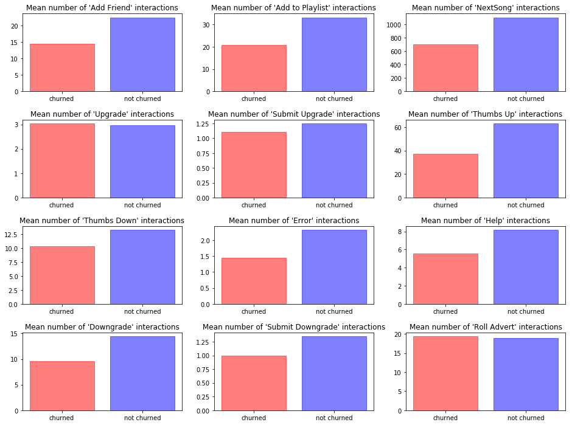

```python
plot_page_churn(["Add Friend", "Add to Playlist", "NextSong", "Upgrade", "Submit Upgrade",
                 "Thumbs Up", "Thumbs Down", "Error", "Help", "Downgrade", "Submit Downgrade", "Roll Advert"])
```

> The information contained in the pages visited/clicked shows some interesting points. For example users who churn added less friends, added less songs to a playlist and listened to less songs than users who stayed. Users who churn also tend to have less upgrade/downgrade interactions. This is valuable information for creating features for prediction.

```python
def plot_compare_churn(data, grpby, scale):
    """
    Plot a stacked bar chart for categorical data
    INPUTS:
    data: pre-filtered data with userId, usr_churn and category to plot
    grpby: category to plot
    scale: maximum y-axis value
    """

    locs = data.select(grpby).distinct()

    churn = locs.join(data.filter("usr_churn == 1").groupby(grpby) \
                      .agg(F.countDistinct("userId").alias("cnt")) \
                      .drop("userID"), on=grpby, how="left").fillna(0).toPandas()
    no_churn = locs.join(data.filter("usr_churn == 0").groupby(grpby) \
                         .agg(F.countDistinct("userId").alias("cnt")) \
                         .drop("userID"), on=grpby, how="left").fillna(0).toPandas()

    churn.cnt = churn.cnt.apply(lambda x: x / churn.cnt.sum() * 100)
    no_churn.cnt = no_churn.cnt.apply(lambda x: x / no_churn.cnt.sum() * 100)

    width = .4
    pos = np.arange(np.max([churn.shape[0], no_churn.shape[0]]))
    rotation = 0
    pwidth = 16
    if len(pos) > 10:
        rotation = 60
    plt.figure(figsize=(pwidth, 3));

    plt.bar(pos - (width/2), churn.cnt, color=[1, 0, 0], alpha=0.5, width=width, edgecolor='r');
    plt.bar(pos + (width/2), no_churn.cnt, color=[0, 0, 1], alpha=0.5, width=width, edgecolor='b');
    plt.title(grpby + " distribution of users");
    plt.ylabel("% of users");
    plt.ylim([0, scale]);
    plt.xticks(pos, churn[grpby].values, rotation=rotation);
    plt.legend(["churn", "stay"]);
```

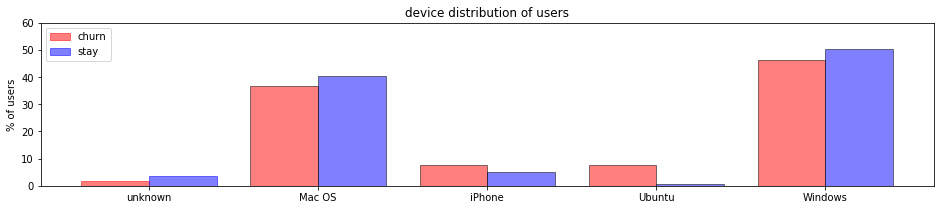

```python
plot_compare_churn(sdf.select("userId", "device", "usr_churn"), "device", 60)
```

> Looking at churning users the percentage of Ubuntu users is much higher, the number of iPhone users slightly higher compared to users who stay. Maybe the user experience on those devices isn't as good.

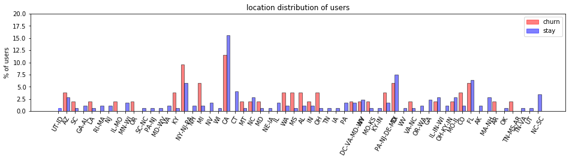

```python
plot_compare_churn(sdf.select("userId", "location", "usr_churn"), "location", 20)
```

> Since the users are widely spread around states, there is no clear difference visible between churning and staying users.  
> Due to the very many different countries and no clear differentiation, this feature is not used for model building.

# Feature Engineering

During data exploration important features have been identified and preprocessed to be combined to a dataset to use with machine learning algorithms.  
The process of creating different features was therefore included in Data exploration, Part 2 - comparing churning vs. staying users & feature creation. In this section those features are combined to the feature dataset.

#### The following features will be included, based on the userId:

- membership_duration: *length of membership in days*
- days_active: *number of active days during membership*
- active_rate: *percentage of active days during membership*
- paid_sub_share: *percentage of membership with paid subscription (week based)*
- paid_use_share: *percentage of interactions with paid subscription (interaction based)*
- page_*: *total number of interactions/website visits*
- device_*: *device used by the user for streaming*
- avg_session_len: *average interactions in one session*
- avg_day_len: *average daily listining time*
- gender: *differentiate male/female users*

#### Numeric encoding:

Columns with categorical values have been numerically encoded:

- gender: male = 0 / female = 1
- level: free = 0 / paid = 1

The features page* and device* have been pivoted to columns with count values.

```python
# join features into one feature-dataset
feature_sdf = features.join(feat_membership, on=['userId'], how='left') \
                    .join(feat_level_interactions, on=['userId'], how='left') \
                    .join(feat_level_subscription, on=['userId'], how='left') \
                    .join(feat_page, on=['userId'], how='left') \
                    .join(feat_device, on=['userId'], how='left') \
                    .join(feat_session_length, on=['userId'], how='left') \
                    .join(feat_daily_time, on=['userId'], how='left') \
                    .join(feat_gender, on=['userId'], how='left') \
                    .drop("userId")
```

```python
feature_df = feature_sdf.toPandas()
print(f"Size of feature dataframe: {feature_df.shape[1]} columns / {feature_df.shape[0]} rows")
d(feature_df.head(3))
```

```
Size of feature dataframe: 28 columns / 225 rows
```

|  | churn_flag | membership_duration | days_active | active_rate | paid_use_share | paid_sub_share | page_About | page_AddFriend | page_AddtoPlaylist | page_Downgrade | ... | page_ThumbsUp | page_Upgrade | device_MacOS | device_Ubuntu | device_Windows | device_iPhone | device_unknown | avg_session_len | avg_day_len | gender |
| --- | --- | --- | --- | --- | --- | --- | --- | --- | --- | --- | --- | --- | --- | --- | --- | --- | --- | --- | --- | --- | --- |
| 0 | 0 | 55 | 7 | 0.13 | 0.00 | 0.00 | 1 | 4 | 7 | 0 | ... | 17 | 2 | 0 | 0 | 0 | 1 | 0 | 54.43 | 9562 | 1 |
| 1 | 0 | 70 | 8 | 0.11 | 0.75 | 0.64 | 3 | 4 | 8 | 5 | ... | 21 | 2 | 0 | 0 | 0 | 1 | 0 | 79.00 | 13429 | 0 |
| 2 | 1 | 71 | 1 | 0.01 | 0.00 | 0.00 | 0 | 0 | 0 | 0 | ... | 0 | 0 | 1 | 0 | 0 | 0 | 0 | 11.00 | 2089 | 0 |

3 rows × 28 columns

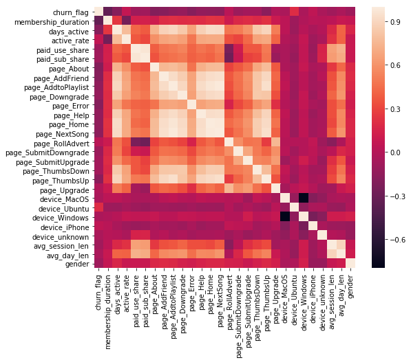

```python
# correlation of features
plt.figure(figsize=(8.5, 7));
sns.heatmap(feature_df.corr());
```

### Export dataset for modeling

The dataset is saved to a Parquet file, so it can be loaded again in the modeling notebook. This way no preprocessing steps are necessary in the other notebook.

```python
# save dataframe to a single Parquet file
feature_sdf.coalesce(1).write.format("parquet").mode('overwrite').save("mini_sparkify_feature_data")
```

> The file has to be renamed manually to *mini_sparkify_feature_data.parquet*, since PySpark can't specify a name for file writing.

# Next Steps

The feature dataset created in this notebook is renamed to *mini_sparkify_feature_data.parquet* and used to create models for predicting customer churn in the follow-up notebook Sparkify_Modeling.ipynb.